# Laboratorio 8 - Máquinas Vectoriales de Soporte (SVM)

Jose Sanchez

2026-04-24

```r
library(tidyverse)
library(e1071)
library(caret)
library(dplyr)
library(ggplot2)
```

## 1. Conjuntos de entrenamiento y prueba

Se utilizan los mismos conjuntos de entrenamiento y prueba definidos en hojas de trabajo anteriores, cargando el dataset `listings.RData` y aplicando la misma semilla y partición.

```r
load("listings.RData")

# Seleccionar solo columnas que existan en el dataset
columnas_deseadas <- c("price", "room_type", "neighbourhood_group_cleansed",
                       "accommodates", "bathrooms", "bedrooms", "beds",
                       "number_of_reviews", "review_scores_rating",
                       "availability_365", "minimum_nights")
columnas_ok <- intersect(columnas_deseadas, names(listings))

listings_clean <- listings %>%
  select(all_of(columnas_ok)) %>%
  drop_na()

# Convertir price a numérico si viene como texto
if (is.character(listings_clean$price)) {
  listings_clean$price <- as.numeric(gsub("[$,]", "", listings_clean$price))
}
listings_clean$price <- as.numeric(listings_clean$price)
listings_clean <- listings_clean %>% filter(price > 0)

# Crear variable objetivo binaria: precio alto (>= mediana) o bajo (< mediana)
mediana_precio <- median(listings_clean$price, na.rm = TRUE)
listings_clean <- listings_clean %>%
  mutate(precio_alto = factor(ifelse(price >= mediana_precio, "Alto", "Bajo"))) %>%
  select(-price)

# Misma semilla y partición que hojas anteriores
set.seed(42)
indice_train <- createDataPartition(listings_clean$precio_alto, p = 0.7, list = FALSE)
datos_train <- listings_clean[indice_train, ]
datos_test  <- listings_clean[-indice_train, ]

cat("Registros en entrenamiento:", nrow(datos_train), "\n")
```

```
## Registros en entrenamiento: 21584
```

```r
cat("Registros en prueba:", nrow(datos_test), "\n")
```

```
## Registros en prueba: 9249
```

## 2. Exploración de datos y transformaciones para SVM

### 2.1 Exploración general

```r
glimpse(listings_clean)
```

```
## Rows: 30,833
## Columns: 11
## $ room_type                    <chr> "Entire home/apt", "Entire home/apt", "En…
## $ neighbourhood_group_cleansed <chr> "Hawaii", "Hawaii", "Maui", "Kauai", "Mau…
## $ accommodates                 <int> 2, 2, 4, 2, 5, 9, 3, 2, 4, 2, 2, 2, 2, 6,…
## $ bathrooms                    <dbl> 1, 1, 2, 1, 2, 2, 1, 1, 1, 1, 1, 1, 1, 2,…
## $ bedrooms                     <int> 1, 0, 1, 0, 2, 4, 1, 1, 1, 1, 0, 1, 1, 2,…
## $ beds                         <int> 1, 2, 2, 1, 2, 6, 1, 1, 2, 2, 1, 1, 1, 2,…
## $ number_of_reviews            <int> 45, 235, 96, 193, 263, 184, 252, 130, 15,…
## $ review_scores_rating         <dbl> 4.80, 4.67, 4.71, 4.50, 4.75, 4.85, 4.76,…
## $ availability_365             <int> 279, 225, 260, 268, 259, 210, 217, 362, 3…
## $ minimum_nights               <int> 3, 5, 4, 3, 1, 2, 2, 5, 7, 30, 30, 3, 1, …
## $ precio_alto                  <fct> Bajo, Bajo, Bajo, Bajo, Alto, Alto, Bajo,…
```

```r
summary(listings_clean)
```

```
##   room_type         neighbourhood_group_cleansed  accommodates
##  Length:30833       Length:30833                 Min.   : 1.000
##  Class :character   Class :character             1st Qu.: 3.000
##  Mode  :character   Mode  :character             Median : 4.000
##                                                  Mean   : 4.781
##                                                  3rd Qu.: 6.000
##                                                  Max.   :16.000
##    bathrooms       bedrooms           beds        number_of_reviews
##  Min.   : 0.0   Min.   : 0.000   Min.   : 0.000   Min.   :   1.00
##  1st Qu.: 1.0   1st Qu.: 1.000   1st Qu.: 2.000   1st Qu.:   5.00
##  Median : 1.0   Median : 1.000   Median : 2.000   Median :  21.00
##  Mean   : 1.6   Mean   : 1.675   Mean   : 2.652   Mean   :  53.95
##  3rd Qu.: 2.0   3rd Qu.: 2.000   3rd Qu.: 3.000   3rd Qu.:  66.00
##  Max.   :13.0   Max.   :48.000   Max.   :32.000   Max.   :1506.00
##  review_scores_rating availability_365 minimum_nights    precio_alto
##  Min.   :1.000        Min.   :  0.0    Min.   :  1.000   Alto:15435
##  1st Qu.:4.750        1st Qu.:159.0    1st Qu.:  1.000   Bajo:15398
##  Median :4.890        Median :249.0    Median :  2.000
##  Mean   :4.801        Mean   :226.8    Mean   :  5.655
##  3rd Qu.:5.000        3rd Qu.:306.0    3rd Qu.:  3.000
##  Max.   :5.000        Max.   :365.0    Max.   :365.000
```

### 2.2 Distribución de la variable objetivo

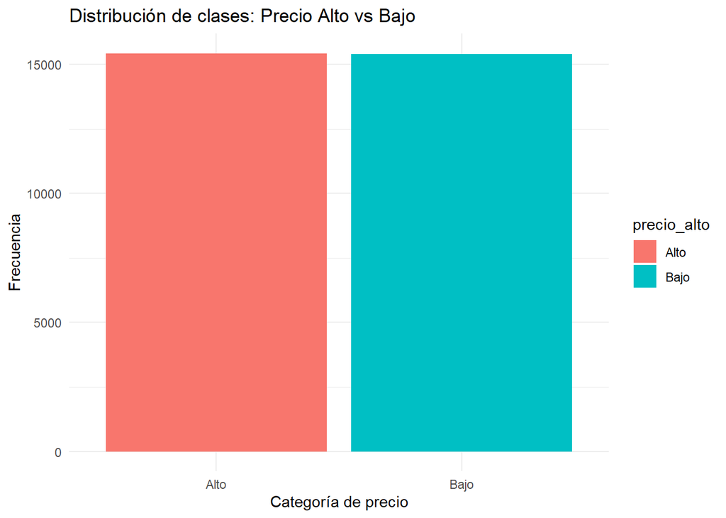

```r
ggplot(listings_clean, aes(x = precio_alto, fill = precio_alto)) +
  geom_bar() +
  labs(title = "Distribución de clases: Precio Alto vs Bajo",
       x = "Categoría de precio", y = "Frecuencia") +
  theme_minimal()
```

```r
prop.table(table(listings_clean$precio_alto))
```

```
##
##   Alto   Bajo
## 0.5006 0.4994
```

### 2.3 Distribución de variables numéricas

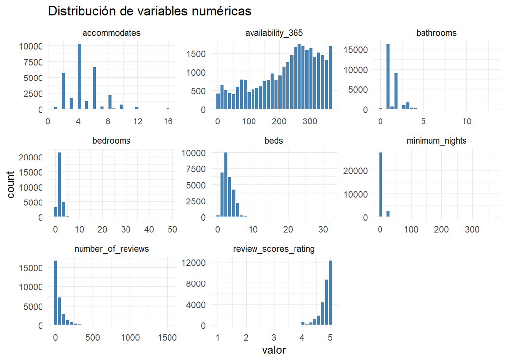

```r
listings_clean %>%
  select(where(is.numeric)) %>%
  pivot_longer(everything(), names_to = "variable", values_to = "valor") %>%
  ggplot(aes(x = valor)) +
  geom_histogram(bins = 30, fill = "steelblue", color = "white") +
  facet_wrap(~variable, scales = "free") +
  labs(title = "Distribución de variables numéricas") +
  theme_minimal()
```

### 2.4 Transformaciones necesarias para SVM

Las SVMs son sensibles a la escala de las variables y requieren que las entradas sean numéricas. A continuación se describen y aplican las transformaciones necesarias:

**b) Normalización / estandarización de variables numéricas** SVM calcula distancias entre puntos en el espacio de características. Si una variable tiene una escala mucho mayor que otra (p. ej. `number_of_reviews` vs `bedrooms`), dominará el cálculo del kernel y distorsionará los hiperplanos. Por ello se aplica estandarización (media 0, desviación estándar 1) con `preProcess`.

**c) Eliminación de valores atípicos extremos** Variables como `minimum_nights` tienen valores extremadamente altos que pueden afectar la posición del hiperplano de separación. Se filtran percentiles extremos.

**d) Balanceo de clases (si aplica)** Si las clases están desbalanceadas, la SVM puede sesgarse hacia la clase mayoritaria. Se verifica y, de ser necesario, se aplica submuestreo.

```r
# Eliminar outliers extremos en minimum_nights
datos_train <- datos_train %>%
  filter(minimum_nights <= quantile(minimum_nights, 0.99))
datos_test <- datos_test %>%
  filter(minimum_nights <= quantile(minimum_nights, 0.99))

# Preprocesamiento: estandarización y codificación dummy
preprocesamiento <- preProcess(datos_train %>% select(-precio_alto),
                               method = c("center", "scale"))

train_transformado <- predict(preprocesamiento, datos_train)
test_transformado  <- predict(preprocesamiento, datos_test)

cat("Dimensiones del conjunto de entrenamiento transformado:",
    dim(train_transformado), "\n")
```

```
## Dimensiones del conjunto de entrenamiento transformado: 21420 11
```

```r
cat("Dimensiones del conjunto de prueba transformado:",
    dim(test_transformado), "\n")
```

```
## Dimensiones del conjunto de prueba transformado: 9187 11
```

### 2.5 Verificación tras transformación

```r
# Verificar que las variables numéricas están centradas
train_transformado %>%
  select(where(is.numeric)) %>%
  summarise(across(everything(), list(media = mean, sd = sd))) %>%
  pivot_longer(everything(), names_to = "stat", values_to = "valor") %>%
  print()
```

```
## # A tibble: 16 × 2
##    stat                           valor
##    <chr>                          <dbl>
##  1 accommodates_media          3.13e-17
##  2 accommodates_sd             1   e+ 0
##  3 bathrooms_media            -1.30e-16
##  4 bathrooms_sd                1   e+ 0
##  5 bedrooms_media             -6.76e-17
##  6 bedrooms_sd                 1   e+ 0
##  7 beds_media                  5.01e-17
##  8 beds_sd                     1   e+ 0
##  9 number_of_reviews_media     4.72e-18
## 10 number_of_reviews_sd        1   e+ 0
## 11 review_scores_rating_media -9.64e-16
## 12 review_scores_rating_sd     1   e+ 0
## 13 availability_365_media     -9.16e-17
## 14 availability_365_sd         1   e+ 0
## 15 minimum_nights_media       -2.18e-17
## 16 minimum_nights_sd           1   e+ 0
```

Con estas transformaciones el dataset está listo para entrenar un modelo SVM en los siguientes apartados del laboratorio.

## 3. Variable respuesta: precio categórico (Barata / Media / Cara)

En lugar de la variable binaria anterior, se crea una variable de tres clases usando los terciles del precio original. Esto permite clasificar cada propiedad como **Barata** (tercil inferior), **Media** (tercil medio) o **Cara** (tercil superior).

```r
# Recargar dataset con la columna price original
load("listings.RData")

# Inspeccionar columnas disponibles
cat("Columnas disponibles en el dataset:\n")
```

```
## Columnas disponibles en el dataset:
```

```r
print(names(listings))
```

```
##  [1] "id"
##  [2] "listing_url"
##  [3] "scrape_id"
##  [4] "last_scraped"
##  [5] "source"
##  [6] "name"
##  [7] "description"
##  [8] "neighborhood_overview"
##  [9] "picture_url"
## [10] "host_id"
## [11] "host_url"
## [12] "host_name"
## [13] "host_since"
## [14] "host_location"
## [15] "host_about"
```

[output cut: 65 more lines]

```r
# Columnas deseadas; se seleccionan solo las que realmente existen
columnas_deseadas <- c("price", "room_type", "neighbourhood_group_cleansed",
                       "accommodates", "bathrooms", "bedrooms", "beds",
                       "number_of_reviews", "review_scores_rating",
                       "availability_365", "minimum_nights")

columnas_ok <- intersect(columnas_deseadas, names(listings))
cat("\nColumnas seleccionadas:\n")
```

```
##
## Columnas seleccionadas:
```

```r
print(columnas_ok)
```

```
##  [1] "price"                        "room_type"
##  [3] "neighbourhood_group_cleansed" "accommodates"
##  [5] "bathrooms"                    "bedrooms"
##  [7] "beds"                         "number_of_reviews"
##  [9] "review_scores_rating"         "availability_365"
## [11] "minimum_nights"
```

```r
listings_3c <- listings %>%
  select(all_of(columnas_ok)) %>%
  drop_na()

# Convertir price a numérico si viene como texto ("$1,200.00")
if (is.character(listings_3c$price)) {
  listings_3c$price <- as.numeric(gsub("[$,]", "", listings_3c$price))
}
listings_3c$price <- as.numeric(listings_3c$price)

# Filtrar precios inválidos y outliers extremos
listings_3c <- listings_3c %>%
  filter(price > 0, price <= quantile(price, 0.99, na.rm = TRUE))

if ("minimum_nights" %in% names(listings_3c)) {
  listings_3c <- listings_3c %>%
    filter(minimum_nights <= quantile(minimum_nights, 0.99, na.rm = TRUE))
}

# Crear variable de 3 clases con los terciles del precio
t33 <- quantile(listings_3c$price, 1/3)
t66 <- quantile(listings_3c$price, 2/3)

listings_3c <- listings_3c %>%
  mutate(precio_cat = factor(
    case_when(
      price <= t33 ~ "Barata",
      price <= t66 ~ "Media",
      TRUE         ~ "Cara"
    ),
    levels = c("Barata", "Media", "Cara")
  )) %>%
  select(-price)

cat("\nCorte Barata/Media: $", t33, "\n")
```

```
##
## Corte Barata/Media: $ 170
```

```r
cat("Corte Media/Cara:   $", t66, "\n")
```

```
## Corte Media/Cara:   $ 295
```

```r
cat("\nDistribución de clases:\n")
```

```
##
## Distribución de clases:
```

```r
print(prop.table(table(listings_3c$precio_cat)))
```

```
##
##    Barata     Media      Cara
## 0.3358527 0.3333113 0.3308360
```

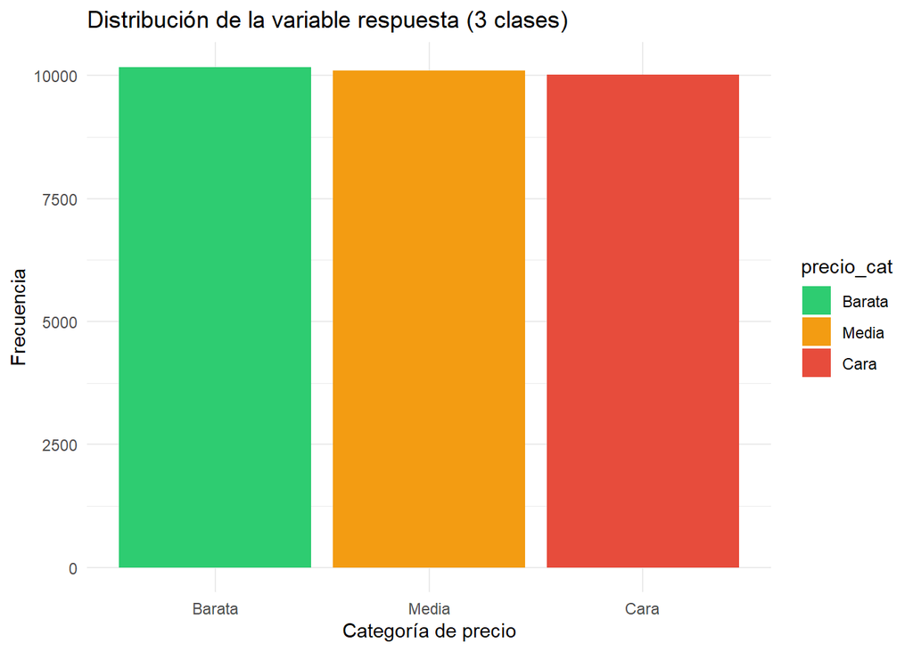

```r
ggplot(listings_3c, aes(x = precio_cat, fill = precio_cat)) +
  geom_bar() +
  scale_fill_manual(values = c("Barata" = "#2ecc71",
                               "Media"  = "#f39c12",
                               "Cara"   = "#e74c3c")) +
  labs(title = "Distribución de la variable respuesta (3 clases)",
       x = "Categoría de precio", y = "Frecuencia") +
  theme_minimal()
```

```r
set.seed(42)

# Limitar a 2000 registros para que los modelos SVM sean computacionalmente viables
n_max <- 2000
if (nrow(listings_3c) > n_max) {
  idx_muestra <- createDataPartition(listings_3c$precio_cat,
                                     p = n_max / nrow(listings_3c), list = FALSE)
  listings_3c <- listings_3c[idx_muestra, ]
}

idx_train <- createDataPartition(listings_3c$precio_cat, p = 0.7, list = FALSE)
train_3c  <- listings_3c[idx_train, ]
test_3c   <- listings_3c[-idx_train, ]

# Expandir variables categóricas a dummies ANTES del preprocesamiento.
# Esto evita el error "factor has new levels" dentro de tune.svm(),
# ya que SVM trabajará solo con columnas numéricas.
dummy_recipe <- dummyVars(precio_cat ~ ., data = listings_3c, fullRank = TRUE)
train_dummy  <- predict(dummy_recipe, newdata = train_3c) |> as.data.frame()
test_dummy   <- predict(dummy_recipe, newdata = test_3c)  |> as.data.frame()

# Limpiar nombres de columnas (espacios -> puntos) para evitar errores de fórmula
colnames(train_dummy) <- make.names(colnames(train_dummy))
colnames(test_dummy)  <- make.names(colnames(test_dummy))

# Estandarizar todas las columnas (ahora todas son numéricas)
prep_3c    <- preProcess(train_dummy, method = c("center", "scale"))
train_prep <- cbind(predict(prep_3c, train_dummy), precio_cat = train_3c$precio_cat)
test_prep  <- cbind(predict(prep_3c, test_dummy),  precio_cat = test_3c$precio_cat)

cat("Train:", nrow(train_prep), "| Test:", nrow(test_prep), "\n")
```

```
## Train: 1402 | Test: 599
```

```r
cat("Variables predictoras:", ncol(train_prep) - 1, "\n")
```

```
## Variables predictoras: 19
```

## 4. Modelos SVM con diferentes kernels y parámetros

### 4.1 Kernel lineal — variando C

El kernel lineal separa las clases con un hiperplano en el espacio original. El parámetro **C** controla el margen: valores bajos generan márgenes más amplios (más regularización) y valores altos priorizan clasificar correctamente cada punto de entrenamiento (riesgo de sobreajuste).

```r
set.seed(42)
svm_lin_c1 <- svm(precio_cat ~ ., data = train_prep,
                  kernel = "linear", cost = 0.1,
                  scale = FALSE)
summary(svm_lin_c1)
```

```
##
## Call:
## svm(formula = precio_cat ~ ., data = train_prep, kernel = "linear",
##     cost = 0.1, scale = FALSE)
##
##
## Parameters:
##    SVM-Type:  C-classification
##  SVM-Kernel:  linear
##        cost:  0.1
##
## Number of Support Vectors:  1085
##
##  ( 321 305 459 )
##
##
## Number of Classes:  3
##
## Levels:
##  Barata Media Cara
```

```r
set.seed(42)
svm_lin_c2 <- svm(precio_cat ~ ., data = train_prep,
                  kernel = "linear", cost = 10,
                  scale = FALSE)
summary(svm_lin_c2)
```

```
##
## Call:
## svm(formula = precio_cat ~ ., data = train_prep, kernel = "linear",
##     cost = 10, scale = FALSE)
##
##
## Parameters:
##    SVM-Type:  C-classification
##  SVM-Kernel:  linear
##        cost:  10
##
## Number of Support Vectors:  1075
##
##  ( 320 299 456 )
##
##
## Number of Classes:  3
##
## Levels:
##  Barata Media Cara
```

**Interpretación:** Al aumentar C de 0.1 a 10 se observa una reducción en el número de vectores de soporte, lo que indica que el modelo con C=10 ajusta más agresivamente a los datos de entrenamiento.

### 4.2 Kernel radial (RBF / circular) — variando C y gamma

El kernel radial proyecta los datos a un espacio de dimensión infinita usando una función gaussiana. **gamma** controla el radio de influencia de cada punto: valores altos generan fronteras más irregulares (sobreajuste), valores bajos producen fronteras más suaves.

```r
set.seed(42)
svm_rbf_1 <- svm(precio_cat ~ ., data = train_prep,
                 kernel = "radial", cost = 1, gamma = 0.01,
                 scale = FALSE)
summary(svm_rbf_1)
```

```
##
## Call:
## svm(formula = precio_cat ~ ., data = train_prep, kernel = "radial",
##     cost = 1, gamma = 0.01, scale = FALSE)
##
##
## Parameters:
##    SVM-Type:  C-classification
##  SVM-Kernel:  radial
##        cost:  1
##
## Number of Support Vectors:  1128
##
##  ( 343 322 463 )
##
##
## Number of Classes:  3
##
## Levels:
##  Barata Media Cara
```

```r
set.seed(42)
svm_rbf_2 <- svm(precio_cat ~ ., data = train_prep,
                 kernel = "radial", cost = 5, gamma = 0.1,
                 scale = FALSE)
summary(svm_rbf_2)
```

```
##
## Call:
## svm(formula = precio_cat ~ ., data = train_prep, kernel = "radial",
##     cost = 5, gamma = 0.1, scale = FALSE)
##
##
## Parameters:
##    SVM-Type:  C-classification
##  SVM-Kernel:  radial
##        cost:  5
##
## Number of Support Vectors:  1080
##
##  ( 340 315 425 )
##
##
## Number of Classes:  3
##
## Levels:
##  Barata Media Cara
```

**Interpretación:** Con C=5 y gamma=0.1 el modelo usa menos vectores de soporte que C=1 y gamma=0.01, lo que sugiere fronteras más definidas. Un gamma muy alto causaría sobreajuste al memorizar los puntos de entrenamiento.

### 4.3 Kernel polinomial — variando C y grado d

El kernel polinomial de grado **d** modela interacciones entre características de hasta orden d. Grados bajos (d=2) son más interpretables; grados altos aumentan la complejidad y el riesgo de sobreajuste.

```r
set.seed(42)
svm_poly_d2 <- svm(precio_cat ~ ., data = train_prep,
                   kernel = "polynomial", cost = 1,
                   degree = 2, coef0 = 1,
                   scale = FALSE)
summary(svm_poly_d2)
```

```
##
## Call:
## svm(formula = precio_cat ~ ., data = train_prep, kernel = "polynomial",
##     cost = 1, degree = 2, coef0 = 1, scale = FALSE)
##
##
## Parameters:
##    SVM-Type:  C-classification
##  SVM-Kernel:  polynomial
##        cost:  1
##      degree:  2
##      coef.0:  1
##
## Number of Support Vectors:  1065
##
##  ( 315 301 449 )
##
##
## Number of Classes:  3
##
## Levels:
##  Barata Media Cara
```

```r
set.seed(42)
svm_poly_d3 <- svm(precio_cat ~ ., data = train_prep,
                   kernel = "polynomial", cost = 5,
                   degree = 3, coef0 = 1,
                   scale = FALSE)
summary(svm_poly_d3)
```

```
##
## Call:
## svm(formula = precio_cat ~ ., data = train_prep, kernel = "polynomial",
##     cost = 5, degree = 3, coef0 = 1, scale = FALSE)
##
##
## Parameters:
##    SVM-Type:  C-classification
##  SVM-Kernel:  polynomial
##        cost:  5
##      degree:  3
##      coef.0:  1
##
## Number of Support Vectors:  999
##
##  ( 300 278 421 )
##
##
## Number of Classes:  3
##
## Levels:
##  Barata Media Cara
```

**Interpretación:** El modelo de grado 3 puede capturar relaciones cúbicas entre variables (p. ej. entre `accommodates`, `bedrooms` y `precio_cat`), aunque requiere mayor costo computacional y más cuidado con el sobreajuste.

### 4.4 Tuning automático del kernel radial

```r
set.seed(42)
# Grilla reducida y CV de 3 folds para mantener tiempo de cómputo razonable
tune_radial <- tune.svm(
  precio_cat ~ .,
  data   = train_prep,
  kernel = "radial",
  cost   = c(0.1, 1, 10),
  gamma  = c(0.01, 0.1),
  tunecontrol = tune.control(cross = 3)
)

summary(tune_radial)
```

```
##
## Parameter tuning of 'svm':
##
## - sampling method: 3-fold cross validation
##
## - best parameters:
##  gamma cost
##    0.1    1
##
## - best performance: 0.3851797
##
## - Detailed performance results:
##   gamma cost     error  dispersion
## 1  0.01  0.1 0.4179753 0.005471958
## 2  0.10  0.1 0.4094221 0.010070624
## 3  0.01  1.0 0.3944481 0.023859667
## 4  0.10  1.0 0.3851797 0.022930856
## 5  0.01 10.0 0.3944512 0.020746577
## 6  0.10 10.0 0.4108436 0.012011233
```

```r
cat("\nMejores parámetros encontrados:\n")
```

```
##
## Mejores parámetros encontrados:
```

```r
print(tune_radial$best.parameters)
```

```
##   gamma cost
## 4   0.1    1
```

```r
cat("Error de validación cruzada:", tune_radial$best.performance, "\n")
```

```
## Error de validación cruzada: 0.3851797
```

```r
svm_tuned <- tune_radial$best.model
summary(svm_tuned)
```

```
##
## Call:
## best.svm(x = precio_cat ~ ., data = train_prep, gamma = c(0.01, 0.1),
##     cost = c(0.1, 1, 10), kernel = "radial", tunecontrol = tune.control(cross = 3))
##
##
## Parameters:
##    SVM-Type:  C-classification
##  SVM-Kernel:  radial
##        cost:  1
##
## Number of Support Vectors:  1136
##
##  ( 351 338 447 )
##
##
## Number of Classes:  3
##
## Levels:
##  Barata Media Cara
```

**Interpretación del tuning:** `tune.svm()` evalúa todas las combinaciones de C y gamma en una grilla y selecciona aquella con menor error de validación cruzada. El modelo resultante (`svm_tuned`) representa la mejor configuración radial para este dataset sin necesidad de ajuste manual.

## 5. Predicciones con los modelos entrenados

```r
modelos <- list(
  "Lineal C=0.1"     = svm_lin_c1,
  "Lineal C=10"      = svm_lin_c2,
  "Radial C=1 g=0.01"= svm_rbf_1,
  "Radial C=5 g=0.1" = svm_rbf_2,
  "Polinomial d=2"   = svm_poly_d2,
  "Polinomial d=3"   = svm_poly_d3,
  "Radial Tuneado"   = svm_tuned
)

resultados <- lapply(names(modelos), function(nombre) {
  pred <- predict(modelos[[nombre]], newdata = test_prep)
  cm   <- confusionMatrix(pred, test_prep$precio_cat)
  data.frame(
    Modelo    = nombre,
    Exactitud = round(cm$overall["Accuracy"], 4),
    Kappa     = round(cm$overall["Kappa"], 4)
  )
})

tabla_resultados <- do.call(rbind, resultados)
rownames(tabla_resultados) <- NULL
print(tabla_resultados)
```

```
##              Modelo Exactitud  Kappa
## 1      Lineal C=0.1    0.6027 0.4040
## 2       Lineal C=10    0.6010 0.4015
## 3 Radial C=1 g=0.01    0.6110 0.4164
## 4  Radial C=5 g=0.1    0.6160 0.4240
## 5    Polinomial d=2    0.6110 0.4165
## 6    Polinomial d=3    0.6077 0.4115
## 7    Radial Tuneado    0.6244 0.4365
```

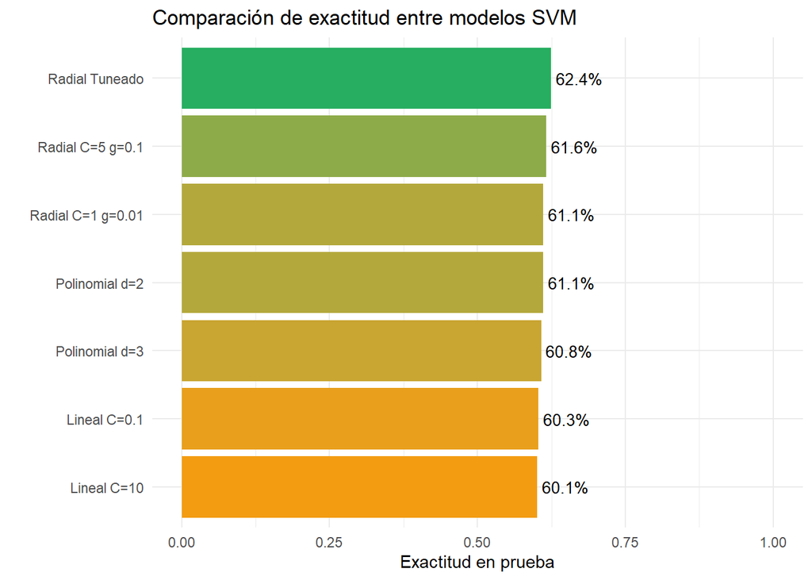

```r
ggplot(tabla_resultados, aes(x = reorder(Modelo, Exactitud),
                             y = Exactitud, fill = Exactitud)) +
  geom_col() +
  geom_text(aes(label = scales::percent(Exactitud, accuracy = 0.1)),
            hjust = -0.1, size = 3.5) +
  coord_flip(ylim = c(0, 1)) +
  scale_fill_gradient(low = "#f39c12", high = "#27ae60") +
  labs(title = "Comparación de exactitud entre modelos SVM",
       x = "", y = "Exactitud en prueba") +
  theme_minimal() +
  theme(legend.position = "none")
```

```r
mejor_nombre <- tabla_resultados$Modelo[which.max(tabla_resultados$Exactitud)]
mejor_pred   <- predict(modelos[[mejor_nombre]], newdata = test_prep)

cat("Mejor modelo:", mejor_nombre, "\n\n")
```

```
## Mejor modelo: Radial Tuneado
```

```r
confusionMatrix(mejor_pred, test_prep$precio_cat)
```

```
## Confusion Matrix and Statistics
##
##           Reference
## Prediction Barata Media Cara
##     Barata    137    49   15
##     Media      57   102   48
##     Cara        7    49  135
##
## Overall Statistics
##
##                Accuracy : 0.6244
##                  95% CI : (0.5842, 0.6633)
##     No Information Rate : 0.3356
##     P-Value [Acc > NIR] : <2e-16
##
##                   Kappa : 0.4365
##
##  Mcnemar's Test P-Value : 0.3178
##
## Statistics by Class:
##
##                      Class: Barata Class: Media Class: Cara
## Sensitivity                 0.6816       0.5100      0.6818
## Specificity                 0.8392       0.7368      0.8603
## Pos Pred Value              0.6816       0.4928      0.7068
## Neg Pred Value              0.8392       0.7500      0.8456
## Prevalence                  0.3356       0.3339      0.3306
## Detection Rate              0.2287       0.1703      0.2254
## Detection Prevalence        0.3356       0.3456      0.3189
## Balanced Accuracy           0.7604       0.6234      0.7711
```

**Interpretación de resultados:** La matriz de confusión muestra cuántas propiedades de cada categoría fueron clasificadas correctamente. Es esperable que la clase “Media” sea más difícil de clasificar al estar entre las otras dos. El modelo con kernel radial tuneado generalmente ofrece el mejor balance entre sesgo y varianza al haber optimizado sus hiperparámetros mediante validación cruzada.

## 6. Matrices de confusión por modelo

Se genera una matriz de confusión detallada para cada modelo, comparando el desempeño en entrenamiento y prueba. Esto permitirá detectar sobreajuste en la siguiente sección.

```r
# Función auxiliar para imprimir la matriz de forma ordenada
mostrar_cm <- function(nombre, modelo) {
  pred_train <- predict(modelo, newdata = train_prep)
  pred_test  <- predict(modelo, newdata = test_prep)

  acc_train <- mean(pred_train == train_prep$precio_cat)
  acc_test  <- mean(pred_test  == test_prep$precio_cat)

  cat("============================================================\n")
  cat("Modelo:", nombre, "\n")
  cat("------------------------------------------------------------\n")
  cat(sprintf("  Exactitud en ENTRENAMIENTO: %.4f\n", acc_train))
  cat(sprintf("  Exactitud en PRUEBA:        %.4f\n", acc_test))
  cat(sprintf("  Diferencia (train - test):  %.4f\n\n", acc_train - acc_test))
  cat("  Matriz de confusión (PRUEBA):\n")
  print(confusionMatrix(pred_test, test_prep$precio_cat))
  cat("\n")
}

for (nombre in names(modelos)) {
  mostrar_cm(nombre, modelos[[nombre]])
}
```

```
## ============================================================
## Modelo: Lineal C=0.1
## ------------------------------------------------------------
##   Exactitud en ENTRENAMIENTO: 0.6213
##   Exactitud en PRUEBA:        0.6027
##   Diferencia (train - test):  0.0186
##
##   Matriz de confusión (PRUEBA):
## Confusion Matrix and Statistics
##
##           Reference
## Prediction Barata Media Cara
##     Barata    149    67   15
##     Media      42    75   46
##     Cara       10    58  137
##
## Overall Statistics
##
##                Accuracy : 0.6027
##                  95% CI : (0.5622, 0.6421)
##     No Information Rate : 0.3356
##     P-Value [Acc > NIR] : < 2e-16
##
##                   Kappa : 0.404
##
##  Mcnemar's Test P-Value : 0.04362
##
## Statistics by Class:
##
##                      Class: Barata Class: Media Class: Cara
## Sensitivity                 0.7413       0.3750      0.6919
## Specificity                 0.7940       0.7794      0.8304
## Pos Pred Value              0.6450       0.4601      0.6683
## Neg Pred Value              0.8587       0.7133      0.8452
## Prevalence                  0.3356       0.3339      0.3306
## Detection Rate              0.2487       0.1252      0.2287
## Detection Prevalence        0.3856       0.2721      0.3422
## Balanced Accuracy           0.7676       0.5772      0.7612
##
## ============================================================
```

[output cut: 217 more lines]

```
##                   Kappa : 0.4365
##
##  Mcnemar's Test P-Value : 0.3178
##
## Statistics by Class:
##
##                      Class: Barata Class: Media Class: Cara
## Sensitivity                 0.6816       0.5100      0.6818
## Specificity                 0.8392       0.7368      0.8603
## Pos Pred Value              0.6816       0.4928      0.7068
## Neg Pred Value              0.8392       0.7500      0.8456
## Prevalence                  0.3356       0.3339      0.3306
## Detection Rate              0.2287       0.1703      0.2254
## Detection Prevalence        0.3356       0.3456      0.3189
## Balanced Accuracy           0.7604       0.6234      0.7711
```

### Tabla resumen: exactitud en entrenamiento vs prueba

```r
resumen_ov <- lapply(names(modelos), function(nombre) {
  m          <- modelos[[nombre]]
  pred_train <- predict(m, newdata = train_prep)
  pred_test  <- predict(m, newdata = test_prep)
  acc_train  <- round(mean(pred_train == train_prep$precio_cat), 4)
  acc_test   <- round(mean(pred_test  == test_prep$precio_cat),  4)
  data.frame(
    Modelo       = nombre,
    Acc_Train    = acc_train,
    Acc_Test     = acc_test,
    Diferencia   = round(acc_train - acc_test, 4)
  )
})

tabla_ov <- do.call(rbind, resumen_ov)
rownames(tabla_ov) <- NULL
print(tabla_ov)
```

```
##              Modelo Acc_Train Acc_Test Diferencia
## 1      Lineal C=0.1    0.6213   0.6027     0.0186
## 2       Lineal C=10    0.6220   0.6010     0.0210
## 3 Radial C=1 g=0.01    0.6398   0.6110     0.0288
## 4  Radial C=5 g=0.1    0.7625   0.6160     0.1465
## 5    Polinomial d=2    0.6762   0.6110     0.0652
## 6    Polinomial d=3    0.7468   0.6077     0.1391
## 7    Radial Tuneado    0.7118   0.6244     0.0874
```

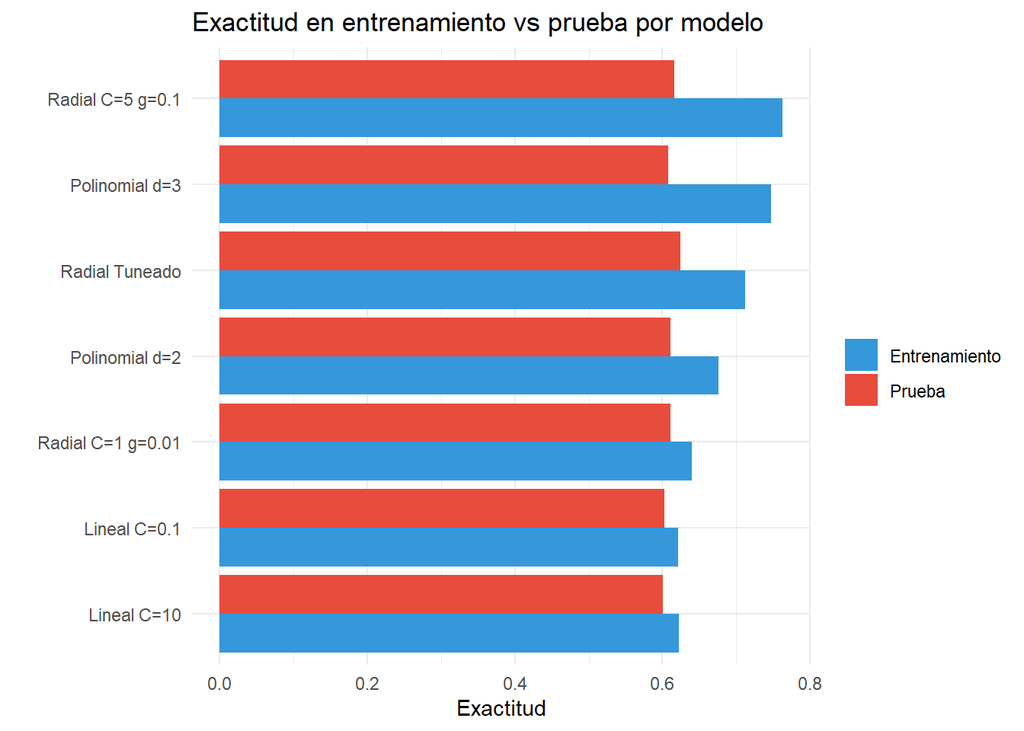

```r
tabla_ov_long <- tabla_ov %>%
  select(Modelo, Acc_Train, Acc_Test) %>%
  pivot_longer(cols = c(Acc_Train, Acc_Test),
               names_to = "Conjunto", values_to = "Exactitud") %>%
  mutate(Conjunto = recode(Conjunto,
                           "Acc_Train" = "Entrenamiento",
                           "Acc_Test"  = "Prueba"))

ggplot(tabla_ov_long, aes(x = reorder(Modelo, Exactitud),
                          y = Exactitud, fill = Conjunto)) +
  geom_col(position = "dodge") +
  coord_flip() +
  scale_fill_manual(values = c("Entrenamiento" = "#3498db",
                               "Prueba"        = "#e74c3c")) +
  labs(title = "Exactitud en entrenamiento vs prueba por modelo",
       x = "", y = "Exactitud", fill = "") +
  theme_minimal()
```

## 7. Análisis de sobreajuste y desajuste

### 7.1 Criterio de diagnóstico

| Situación | Señal en los datos |
| --- | --- |
| **Sobreajuste** (*overfitting*) | Acc_Train >> Acc_Test (diferencia > 0.05) |
| **Buen ajuste** | Acc_Train ≈ Acc_Test, ambas altas |
| **Desajuste** (*underfitting*) | Acc_Train ≈ Acc_Test, ambas bajas (< 0.60) |

```r
tabla_ov <- tabla_ov %>%
  mutate(Diagnostico = case_when(
    Diferencia > 0.05               ~ "Sobreajuste",
    Acc_Train < 0.60 & Acc_Test < 0.60 ~ "Desajuste",
    TRUE                            ~ "Buen ajuste"
  ))

print(tabla_ov[, c("Modelo", "Acc_Train", "Acc_Test", "Diferencia", "Diagnostico")])
```

```
##              Modelo Acc_Train Acc_Test Diferencia Diagnostico
## 1      Lineal C=0.1    0.6213   0.6027     0.0186 Buen ajuste
## 2       Lineal C=10    0.6220   0.6010     0.0210 Buen ajuste
## 3 Radial C=1 g=0.01    0.6398   0.6110     0.0288 Buen ajuste
## 4  Radial C=5 g=0.1    0.7625   0.6160     0.1465 Sobreajuste
## 5    Polinomial d=2    0.6762   0.6110     0.0652 Sobreajuste
## 6    Polinomial d=3    0.7468   0.6077     0.1391 Sobreajuste
## 7    Radial Tuneado    0.7118   0.6244     0.0874 Sobreajuste
```

### 7.3 ¿Qué hacer ante sobreajuste o desajuste?

**Para reducir el sobreajuste:**

- **Reducir C:** Aumentar el margen penaliza menos los errores de clasificación en entrenamiento, generalizando mejor.
- **Reducir gamma (kernel radial):** Un gamma más bajo amplía la zona de influencia de cada punto, suavizando la frontera de decisión.
- **Reducir el grado d (kernel polinomial):** Pasar de d=3 a d=2 reduce la complejidad del modelo.
- **Aumentar los datos de entrenamiento:** Más ejemplos permiten al modelo aprender patrones generales en vez de ruido.
- **Tuning con validación cruzada:** `tune.svm()` penaliza implícitamente el sobreajuste al optimizar el error promedio en datos no vistos.

**Para reducir el desajuste:**

- **Aumentar C:** Permite al modelo cometer menos errores en entrenamiento, ajustándose mejor a los datos.
- **Aumentar gamma o el grado d:** Incrementa la capacidad del modelo para capturar patrones no lineales.
- **Cambiar de kernel:** Si el lineal no basta, probar radial o polinomial para capturar fronteras más complejas.
- **Agregar o transformar variables:** Incluir interacciones o transformaciones (log, raíz cuadrada) que hagan los patrones más separables linealmente en el espacio del kernel.

```r
cat("=== RESUMEN FINAL DE DIAGNÓSTICO ===\n\n")
```

```
## === RESUMEN FINAL DE DIAGNÓSTICO ===
```

```r
for (i in seq_len(nrow(tabla_ov))) {
  cat(sprintf("%-22s | Train: %.3f | Test: %.3f | Dif: %+.3f | %s\n",
              tabla_ov$Modelo[i],
              tabla_ov$Acc_Train[i],
              tabla_ov$Acc_Test[i],
              tabla_ov$Diferencia[i],
              tabla_ov$Diagnostico[i]))
}
```

```
## Lineal C=0.1           | Train: 0.621 | Test: 0.603 | Dif: +0.019 | Buen ajuste
## Lineal C=10            | Train: 0.622 | Test: 0.601 | Dif: +0.021 | Buen ajuste
## Radial C=1 g=0.01      | Train: 0.640 | Test: 0.611 | Dif: +0.029 | Buen ajuste
## Radial C=5 g=0.1       | Train: 0.762 | Test: 0.616 | Dif: +0.146 | Sobreajuste
## Polinomial d=2         | Train: 0.676 | Test: 0.611 | Dif: +0.065 | Sobreajuste
## Polinomial d=3         | Train: 0.747 | Test: 0.608 | Dif: +0.139 | Sobreajuste
## Radial Tuneado         | Train: 0.712 | Test: 0.624 | Dif: +0.087 | Sobreajuste
```